# Linear Regression II

2024-10-31

## Math 2265 Chapter 8. Linear Regression

- Work as a group!
- You will need to replace `"ans"` or `your_answer` in the source code
- Update your name in L3
- Add your group members’ name below; students may lose one point if Question 0 is unanswered
- Make sure you save and `knit` your work (to html or pdf) before submitting it to Canvas
- Please only submit your work if you attended the class and worked with other students; this is not an online course

### Goal

1. Inference using a linear model
2. Apply linear regression to a real work data set

### Question 0. Who are your group members? (List their first names)

**Answer:**

### If you need more time to get used to `Markdown`, use the `Visual` mode.

The icon is located in the upper-left corner next to `source`.

### `duke_forest`: Sale prices of houses in Duke Forest, Durham, NC

Data Set: `duke_forest`.

We will work with the `duke_forest` data set. Write a script to check the number of observations and the names of the variables of the data set.

```r
# write your code
str(duke_forest)
```

```
## tibble [98 × 13] (S3: tbl_df/tbl/data.frame)
##  $ address   : chr [1:98] "1 Learned Pl, Durham, NC 27705" "1616 Pinecrest Rd, Durham, NC 27705" "2418 Wrightwood Ave, Durham, NC 27705" "2527 Sevier St, Durham, NC 27705" ...
##  $ price     : num [1:98] 1520000 1030000 420000 680000 428500 ...
##  $ bed       : num [1:98] 3 5 2 4 4 3 5 4 4 3 ...
##  $ bath      : num [1:98] 4 4 3 3 3 3 5 3 5 2 ...
##  $ area      : num [1:98] 6040 4475 1745 2091 1772 ...
##  $ type      : chr [1:98] "Single Family" "Single Family" "Single Family" "Single Family" ...
##  $ year_built: num [1:98] 1972 1969 1959 1961 2020 ...
##  $ heating   : chr [1:98] "Other, Gas" "Forced air, Gas" "Forced air, Gas" "Heat pump, Other, Electric, Gas" ...
##  $ cooling   : Factor w/ 2 levels "other","central": 2 2 2 2 2 2 2 2 2 1 ...
##  $ parking   : chr [1:98] "0 spaces" "Carport, Covered" "Garage - Attached, Covered" "Carport, Covered" ...
##  $ lot       : num [1:98] 0.97 1.38 0.51 0.84 0.16 0.45 0.94 0.79 0.53 0.73 ...
##  $ hoa       : chr [1:98] NA NA NA NA ...
##  $ url       : chr [1:98] "https://www.zillow.com/homedetails/1-Learned-Pl-Durham-NC-27705/49981897_zpid/" "https://www.zillow.com/homedetails/1616-Pinecrest-Rd-Durham-NC-27705/49969247_zpid/" "https://www.zillow.com/homedetails/2418-Wrightwood-Ave-Durham-NC-27705/49972133_zpid/" "https://www.zil…
```

Recall we use linear regression for a pair of numerical variables, explanatory (horizontal, often denoted by x) and response variable (vertical, often denoted by y).

### Task

Save all the numerical variable names as an R vector to the R variable `numerical_variables` below

- Just copy the names from the previous output and paste them as parameters of the vector
- Strings (e.g., variable names) need to be enclosed with quotation marks “variable_name”

```r
# numerical_variable <- c("variable_name1","variable_name2",...,...)
numerical_variable <- c("price","bed","bath","area","year_built","lot")
numerical_variable
```

```
## [1] "price"      "bed"        "bath"       "area"       "year_built"
## [6] "lot"
```

Among the variables we will use `price` as the response variable. The goal is to find the **most suitable explanatory variable** for linear regression. The word *most* requires justification, and we will use two crietria:

1. The correlation coefficient $R$.
2. The sum of squared residuals with respect to the least squares line.

## Best with respect to the correlation coefficient

To do this, we will need to compute the correlation coefficients of `price` over all the rest of the numerical variables you found above. Use the following block to compute the correlation coefficients.

```r
###
#cor_1 <-
#cor_2 <-
#cor_3 <-
#cor_4 <-
#cor_5 <-
#cor_6 <-
#cor_7 <-
#cor_8 <-
# use as many as you need and delete unused ones

cor_1 <- cor(x=duke_forest$price, y=duke_forest$bed)
cor_2 <- cor(x=duke_forest$price, y=duke_forest$bath)
cor_3 <- cor(x=duke_forest$price, y=duke_forest$area)
cor_4 <- cor(x=duke_forest$price, y=duke_forest$year_built)
cor_5 <- cor(x=duke_forest$price, y=duke_forest$lot)

# cor_vec <- c(cor_1, cor_2, cor_3, your_answer, your_answer, ... )
cor_vec <- c(cor_1, cor_2, cor_3, cor_4, cor_5)
cor_vec
```

```
## [1] 0.4105010 0.5886360 0.6672290 0.2018445        NA
```

One of the results may be “NA” since that variable has missing value(s), and we won’t use it for this worksheet.

Use `sort`, `max`, or `min` to determine the best one. Recall when determining the best, we need to consider their absolute values.

```r
sort(abs(cor_vec))
```

```
## [1] 0.2018445 0.4105010 0.5886360 0.6672290
```

**Question:** Which variables are linearly associated `price`?

Write the top two:

## Best with respect to the least squares line

To do this, we will use `lm`. However, to use linear regression, we need to check that the variables are linearly associated with `price`. We can check it with their scatter plots.

In the next cell, make scatter plots for each of the explanatory variables.

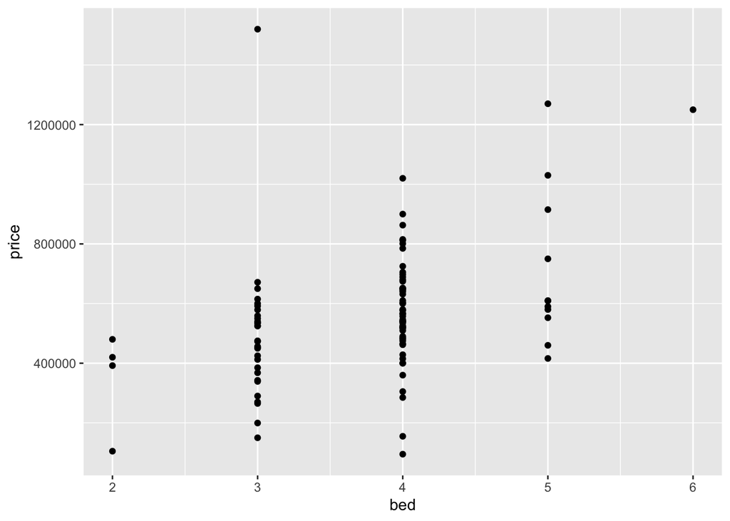

```r
# ggplot(data=duke_forest, aes(x=your_naswer,y=price))+
#   geom_point()
#
# ggplot(data=duke_forest, aes(x=your_naswer,y=price))+
#   geom_point()
#
# ggplot(data=duke_forest, aes(x=your_naswer,y=price))+
#   geom_point()
#
# # Use as many as you need and delete the rest
# ggplot(data=duke_forest, aes(x=your_naswer,y=price))+
#   geom_point()
#
# ggplot(data=duke_forest, aes(x=your_naswer,y=price))+
#   geom_point()
#
# ggplot(data=duke_forest, aes(x=your_naswer,y=price))+
#   geom_point()

ggplot(data=duke_forest, aes(x=bed,y=price))+
  geom_point()
```

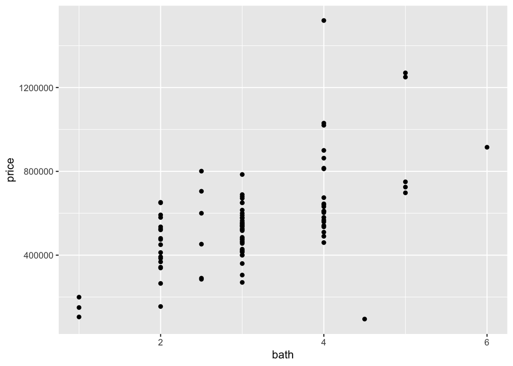

```r
ggplot(data=duke_forest, aes(x=bath,y=price))+
  geom_point()
```

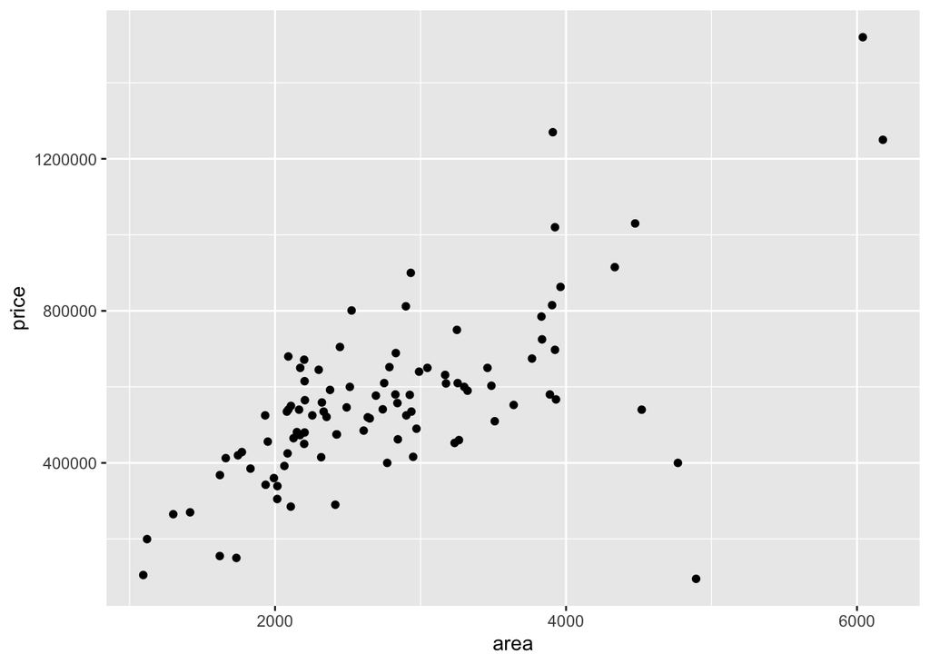

```r
ggplot(data=duke_forest, aes(x=area,y=price))+
  geom_point()
```

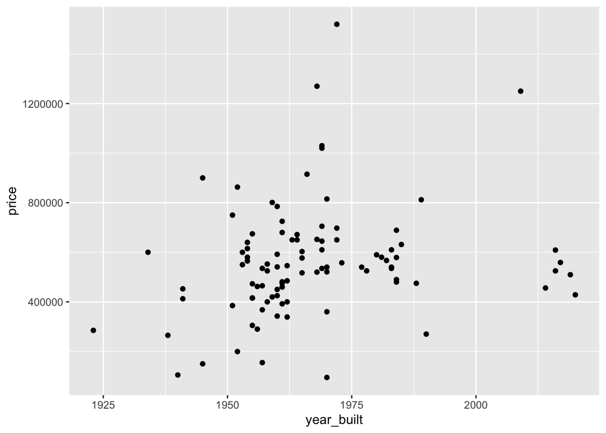

```r
ggplot(data=duke_forest, aes(x=year_built,y=price))+
  geom_point()
```

**Question:** Which two variables have the strongest linear association with `price`.

Answer:

Now, we will use `lm` to find the least squares line and the sum of squared residuals for these two variables.

### Task

Save the linear model for your 1st choice

```r
# model1 <- lm( price ~ your_answer, data=duke_forest)
model1 <- lm( price ~ area, data=duke_forest)
summary(model1)
```

```
##
## Call:
## lm(formula = price ~ area, data = duke_forest)
##
## Residuals:
##     Min      1Q  Median      3Q     Max
## -802163  -70824   -3786   85449  529928
##
## Coefficients:
##              Estimate Std. Error t value Pr(>|t|)
## (Intercept) 116652.33   53302.46   2.188   0.0311 *
## area           159.48      18.17   8.777 6.29e-14 ***
## ---
## Signif. codes:  0 '***' 0.001 '**' 0.01 '*' 0.05 '.' 0.1 ' ' 1
##
## Residual standard error: 168800 on 96 degrees of freedom
## Multiple R-squared:  0.4452, Adjusted R-squared:  0.4394
## F-statistic: 77.03 on 1 and 96 DF,  p-value: 6.292e-14
```

Compute the sum of the squared residuals and save it to `ssr1`.

```r
# ssr1 <- sum( your_answer)
ssr1 <- sum( residuals(model1)^2 )
ssr1
```

```
## [1] 2.735303e+12
```

Save the linear model for your 2nd choice

```r
# model2 <- lm( price ~ your_answer, data=duke_forest)
model2 <- lm( price ~ year_built, data=duke_forest)
summary(model2)
```

```
##
## Call:
## lm(formula = price ~ year_built, data = duke_forest)
##
## Residuals:
##     Min      1Q  Median      3Q     Max
## -472194 -121367  -29801   87334  947858
##
## Coefficients:
##             Estimate Std. Error t value Pr(>|t|)
## (Intercept) -4306458    2410117  -1.787   0.0771 .
## year_built      2474       1225   2.019   0.0463 *
## ---
## Signif. codes:  0 '***' 0.001 '**' 0.01 '*' 0.05 '.' 0.1 ' ' 1
##
## Residual standard error: 222000 on 96 degrees of freedom
## Multiple R-squared:  0.04074,    Adjusted R-squared:  0.03075
## F-statistic: 4.077 on 1 and 96 DF,  p-value: 0.04625
```

Compute the sum of the squared residuals and save it to `ssr2`.

```r
# ssr2 <- sum( your_answer)
ssr2 <- sum( residuals(model2)^2 )
ssr2
```

```
## [1] 4.72934e+12
```

Execute the next line to compare the results.

```r
if(ssr1 < ssr2) {
  print("Your 1st choice has lower error. Use this to make a prediction in the next part.")
} else {
  print("Your 2nd choice has lower error. Use this to make a prediction in the next part.")
}
```

```
## [1] "Your 1st choice has lower error. Use this to make a prediction in the next part."
```

### Question:

Which variable explains the responds variable `price` better?

Answer:

### Make prediction based on your model

First plot the least squares line. Use your answer above as your explanatory variable.

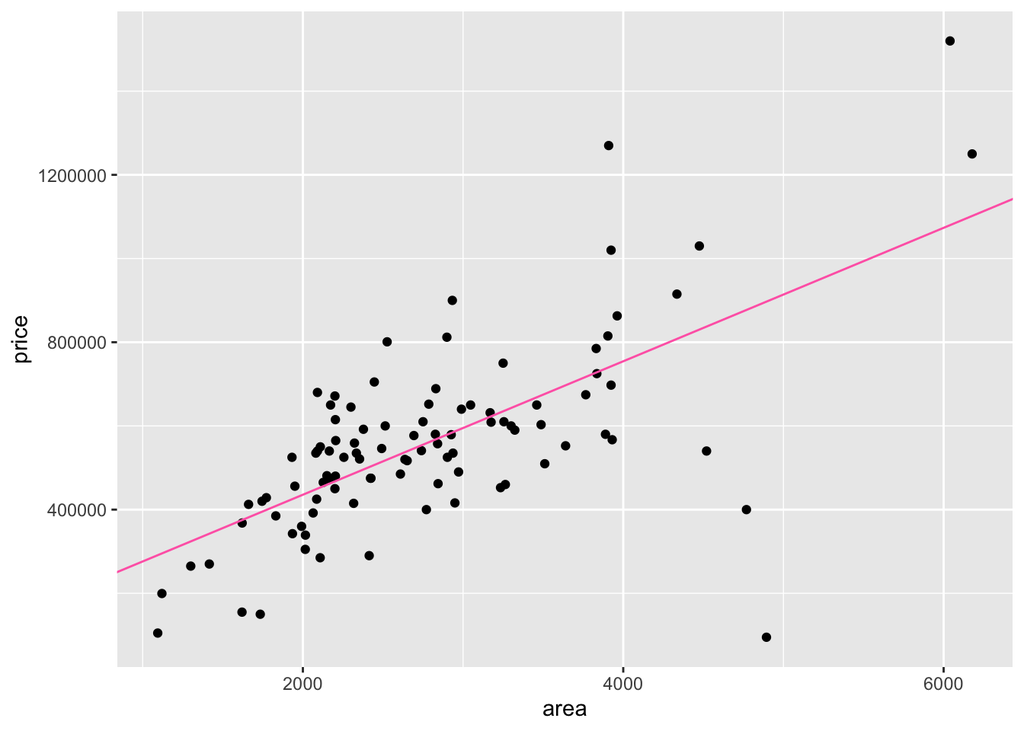

```r
# ggplot(data=duke_forest, aes(x = your_answer, y = price)) +
#   geom_point() +
#   geom_abline(intercept = your_answer, slope = your_answer, color='hotpink')

ggplot(data=duke_forest, aes(x = area, y = price)) +
  geom_point() +
  geom_abline(intercept = 116652.33 , slope = 159.48, color='hotpink')
```

Make a prediction where your $x$ value is the median and mean of your variable. That is if your variable is called `my_expanatory_variable`, $x = median(my_expanatory_variable)$ or $x = mean(my_expanatory_variable)$.

```r
# x <- median(duke_forest$my_expanatory_variable)
# or use mean (or do both)
# x <- mean(duke_forest$my_expanatory_variable)
x <- median(duke_forest$area)

y_hat <- function(x) {
  # intercept + slope * x
  116652.33 + 159.48 * x
}

# You do not need to modify the following two lines. It will print the outcome.
print(paste("For", x, "y_hat(x) = ", y_hat(x)))
```

```
## [1] "For 2623 y_hat(x) =  534968.37"
```

```r
print(paste("That is, for a house of your variable ", x, "the estimated price is $", y_hat(x)))
```

```
## [1] "That is, for a house of your variable  2623 the estimated price is $ 534968.37"
```

## Please only submit your work if you attended the class and worked with other students; this is not an online course

## Complete the handout as a group, and turn it in to the instructor

### Share your work and help your group members before uploading your work to Canvas